# Practica DataDriven

## Presentación y Geolocalización de Malware

En el presente Markdown se van a presentar los principales paises generadores de Malware según el listado extraido de FireHol del feed de Malware.

En el siguiente mapa se muestra la distribución de Malware por paises:

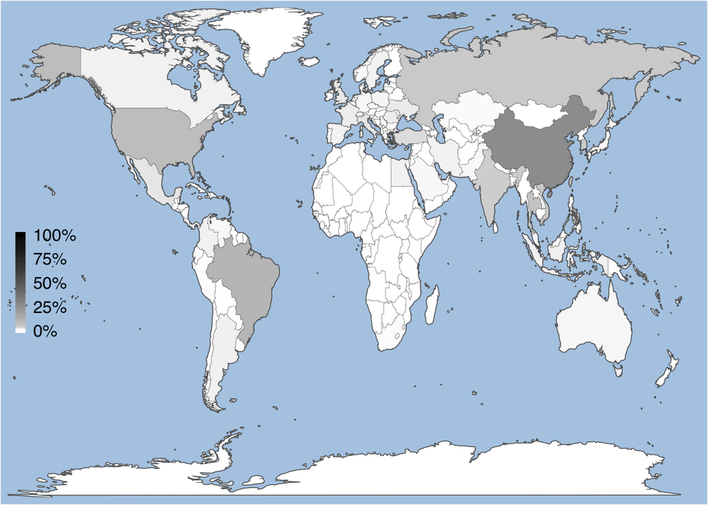

En la siguiente tabla se muestra la cantidad de incidencias agrupadas por pais:

Country

n

China

20651

Brazil

8964

United States

6597

Taiwan, Province of China

6130

Thailand

4952

4340

Russian Federation

3229

Viet Nam

3170

Korea, Republic of

2368

India

2297

Turkey

1456

Hong Kong

1315

Mexico

1076

Italy

1066

United Kingdom

980

Ukraine

890

Romania

773

France

762

Argentina

629

Indonesia

598

Canada

581

Colombia

571

Iran, Islamic Republic of

559

Egypt

552

Spain

528

Sweden

510

Japan

433

Philippines

430

Poland

414

Greece

406

Malaysia

390

Germany

363

Australia

336

Pakistan

329

Venezuela, Bolivarian Republic of

326

Netherlands

319

Singapore

300

Saudi Arabia

296

Israel

293

Bulgaria

268

Hungary

266

Chile

255

Kazakhstan

180

Bangladesh

174

Norway

160

South Africa

158

United Arab Emirates

138

Belgium

115

Seychelles

112

Denmark

102

Portugal

101

Armenia

99

Serbia

96

Panama

95

Czech Republic

94

Ecuador

93

Latvia

86

Peru

85

Cyprus

84

Tunisia

83

Moldova, Republic of

76

Jordan

73

Paraguay

68

Qatar

68

Bolivia, Plurinational State of

66

Ireland

63

Bahrain

58

Bosnia and Herzegovina

58

Switzerland

56

Belarus

55

Kuwait

53

Dominican Republic

51

Costa Rica

49

Morocco

49

Georgia

48

Austria

47

Lithuania

47

Nigeria

47

Macedonia, The Former Yugoslav Republic of

45

Azerbaijan

43

Kenya

43

Macao

43

Slovenia

43

Cambodia

41

Kyrgyzstan

40

Luxembourg

40

New Zealand

39

Uruguay

38

Palestine, State of

36

Puerto Rico

35

Slovakia

34

Albania

33

Uzbekistan

28

Guatemala

27

Finland

24

Algeria

22

Estonia

22

Nepal

22

Tanzania, United Republic of

22

Trinidad and Tobago

22

Cameroon

21

Lebanon

21

Mozambique

21

Afghanistan

20

Honduras

20

Mongolia

20

Ghana

19

Tajikistan

19

Uganda

18

Brunei Darussalam

17

Iraq

17

Jamaica

17

Curacao

16

Oman

15

Bahamas

14

El Salvador

14

Ethiopia

14

Malta

14

Sudan

14

Croatia

13

Montenegro

12

Sri Lanka

12

Suriname

12

Angola

11

Belize

10

Cote D’ivoire

10

Lao People’s Democratic Republic

10

Madagascar

10

Iceland

9

Reunion

8

Zambia

8

Burundi

7

Libya

7

Guam

6

Myanmar

6

Turkmenistan

6

Virgin Islands, British

6

Maldives

5

Namibia

5

Senegal

5

Syrian Arab Republic

5

Benin

4

Botswana

4

Chad

4

Haiti

4

Martinique

4

Mauritius

4

Sint Maarten (Dutch Part)

4

Tonga

4

Fiji

3

Guyana

3

Lesotho

3

Nicaragua

3

Togo

3

Barbados

2

Gabon

2

Guadeloupe

2

Niger

2

Saint Lucia

2

Swaziland

2

Andorra

1

Anguilla

1

Antigua and Barbuda

1

Aruba

1

Burkina Faso

1

Cabo Verde

1

Cayman Islands

1

Congo

1

Cook Islands

1

Cuba

1

French Guiana

1

Gambia

1

Grenada

1

Malawi

1

Mauritania

1

Northern Mariana Islands

1

Rwanda

1

Somalia

1

Virgin Islands, U.S.

1

Yemen

1

Zimbabwe

1